# CASA0005 Week 8 Practical

J Post

2022-12-06

## Preparing the data

Read in datasets to be used:

- Boundary data: London wards (source: [London Data Store](https://data.london.gov.uk/dataset/statistical-gis-boundary-files-london))
- Attribute data: London wards atlas

The file is downloaded directly from the Data Store url, and the **fs** package is used to extract the data from a zip file format.

```r
#If first time running script:

checkfile <- file_exists(here::here("data/statistical-gis-boundaries-london.zip"))

if (checkfile == TRUE){
  Londonwards<-fs::dir_info(here::here("data",
                                 "statistical-gis-boundaries-london",
                                 "ESRI")) %>%
  #$ means exact match
  dplyr::filter(str_detect(path,
                           "London_Ward_CityMerged.shp$"))%>%
  dplyr::select(path)%>%
  dplyr::pull()%>%
  #read in the file in
  sf::st_read()

  cat(cyan("\nAlready loaded!\n"))

} else {
  download.file("https://data.london.gov.uk/download/statistical-gis-boundary-files-london/9ba8c833-6370-4b11-abdc-314aa020d5e0/statistical-gis-boundaries-london.zip",
              destfile="data/statistical-gis-boundaries-london.zip")

listfiles<-dir_info(here::here("data")) %>%
  dplyr::filter(str_detect(path, ".zip")) %>%
  dplyr::select(path) %>%
  pull() %>%
  #print out the .gz file
  print() %>%
  as.character() %>%
  utils::unzip(exdir=here::here("data"))

Londonwards<-fs::dir_info(here::here("data",
                                 "statistical-gis-boundaries-london",
                                 "ESRI")) %>%
  #$ means exact match
  dplyr::filter(str_detect(path,
                           "London_Ward_CityMerged.shp$"))%>%
  dplyr::select(path)%>%
  dplyr::pull()%>%
  #read in the file in
  sf::st_read()

 cat(cyan("\nDownloaded from London Data Store\n"))
}
```

```
##
## Already loaded!
```

```r
# Read in attribute data
LondonWardProfiles <- read_csv(here::here("data","ward-profiles-excel-version.csv"),
                               #Identify missing values in the source file
                               na = c("", "NA", "n/a"),
                               col_names = TRUE,
                               locale = locale(encoding = 'Latin1')) %>%
  clean_names()
# spec(LondonWardProfiles)


# Read in schools point data
ldn_schools <- read_csv(here::here("data", "all_schools_xy_2016.csv"),
                        col_names = TRUE,
                        locale = locale(encoding = 'Latin1')) %>%
  # Convert to spatial object
  st_as_sf(., coords = c("x","y"),
           crs = 4326) %>%
  #Filter to secondary schools
  filter(PHASE == "Secondary")
```

### Check the data

Plot a map of the shapefile data:

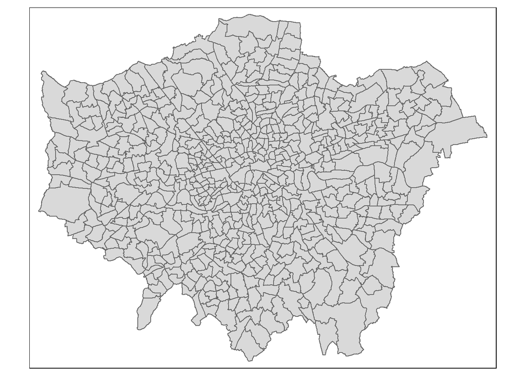

```r
qtm(Londonwards)
```

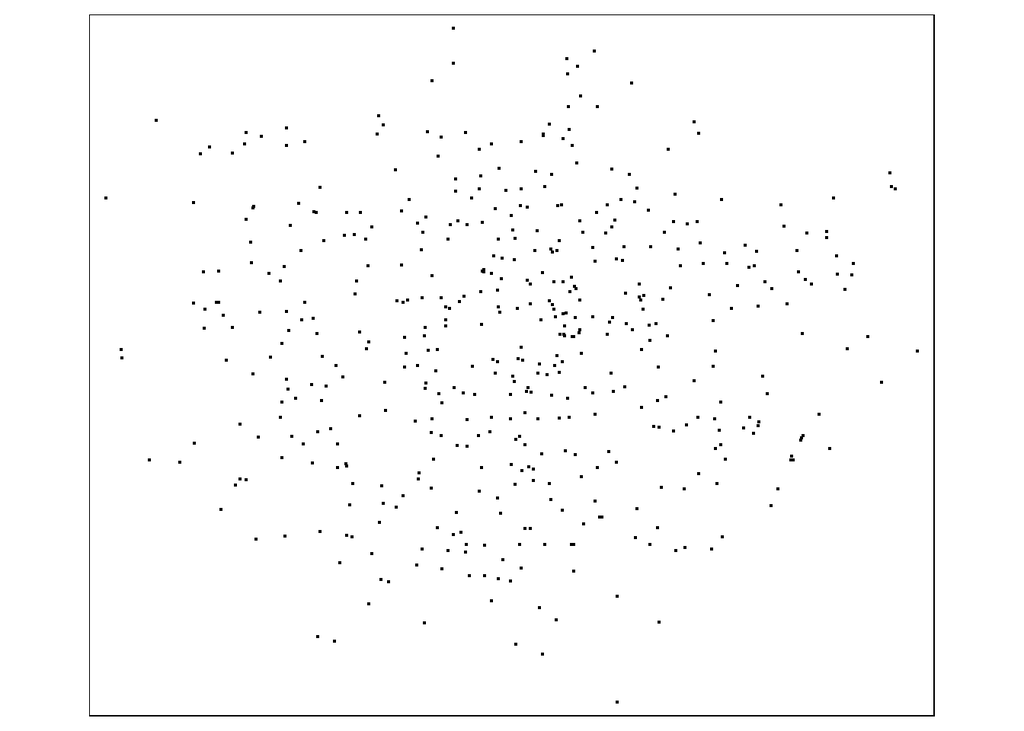

```r
qtm(ldn_schools)
```

```r
# Check CRS for each geofile
check_crs <- append(st_crs(Londonwards), st_crs(ldn_schools))
check_crs[1]
```

```
## $input
## [1] "OSGB36 / British National Grid"
```

```r
check_crs[3]
```

```
## $input
## [1] "EPSG:4326"
```

View a sample of the attribute data:

```r
head(LondonWardProfiles)
```

```
## # A tibble: 6 × 67
##   ward_name      old_c…¹ new_c…² popul…³ child…⁴ worki…⁵ older…⁶ perce…⁷ perce…⁸
##   <chr>          <chr>   <chr>     <dbl>   <dbl>   <dbl>   <dbl>   <dbl>   <dbl>
## 1 City of London 00AA    E09000…    8100     650    6250    1250     8      76.9
## 2 Barking and D… 00ABFX  E05000…   14750    3850   10150     750    26      69
## 3 Barking and D… 00ABFY  E05000…   10600    2700    6800    1050    25.7    64.3
## 4 Barking and D… 00ABFZ  E05000…   12700    3200    8350    1100    25.4    65.9
## 5 Barking and D… 00ABGA  E05000…   10400    2550    6400    1450    24.3    61.5
## 6 Barking and D… 00ABGB  E05000…   10750    2150    7050    1550    20.1    65.7
## # … with 58 more variables: percent_all_older_people_aged_65_2015 <dbl>,
## #   mean_age_2013 <dbl>, median_age_2013 <dbl>, area_square_kilometres <dbl>,
## #   population_density_persons_per_sq_km_2013 <dbl>, percent_bame_2011 <dbl>,
## #   percent_not_born_in_uk_2011 <dbl>,
## #   percent_english_is_first_language_of_no_one_in_household_2011 <dbl>,
## #   general_fertility_rate_2013 <dbl>, male_life_expectancy_2009_13 <dbl>,
## #   female_life_expectancy_2009_13 <dbl>, …
```

### Merge spatial and attribute data

Reproject spatial objects to the same CRS.

Merge the attribute data to the wards shapefile.

```r
#Transform the CRS for school points to the British grid
ldn_schools <- st_transform(ldn_schools, crs = 27700)

wards_merged <- Londonwards %>%
  left_join(LondonWardProfiles, by = c("GSS_CODE" = "new_code")) %>%
  #Select desired columns
  #Note that 'geometry' is sticky - i.e. does not need to be specified in select statement to be retained
  select(NAME, GSS_CODE, BOROUGH,
         population_2015, population_density_persons_per_sq_km_2013,
         average_gcse_capped_point_scores_2014,
         unauthorised_absence_in_all_schools_percent_2013,
         median_house_price_2014)
```

Map the joined file to check the data

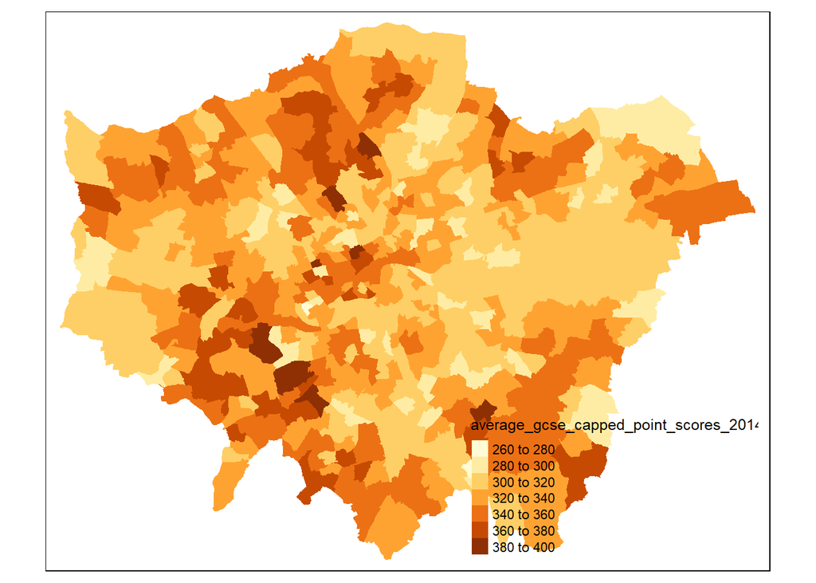

```r
qtm(wards_merged,
    fill = "average_gcse_capped_point_scores_2014",
    borders = NULL)
```

## Regression Model

Start the investigation by fitting a linear regression model to the dependent and independent variables. The first step here is to check the distributions of the input variables.

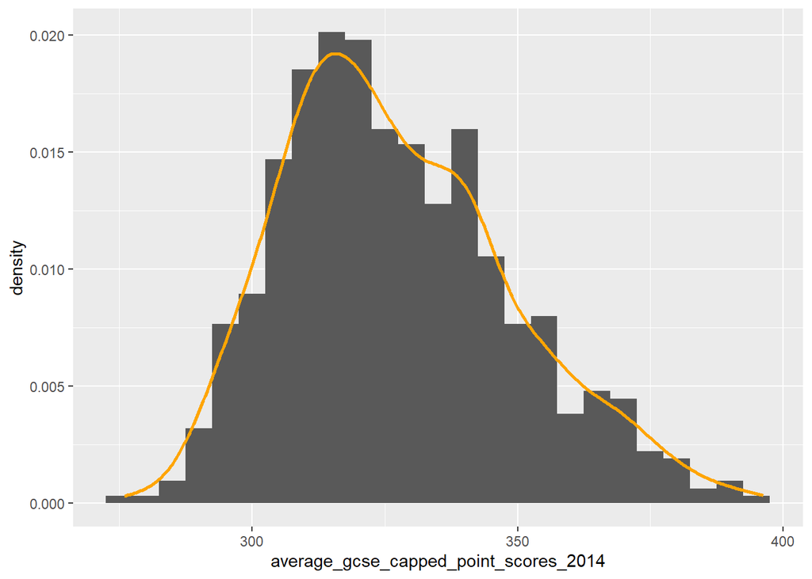

```r
dist_gcse <- ggplot(wards_merged,
                    aes(x = average_gcse_capped_point_scores_2014)) +
  geom_histogram(aes(y = ..density..),
                 binwidth = 5) +
  #Add density line
  geom_density(colour = "orange",
               linewidth = 1, adjust = 1)
dist_gcse
```

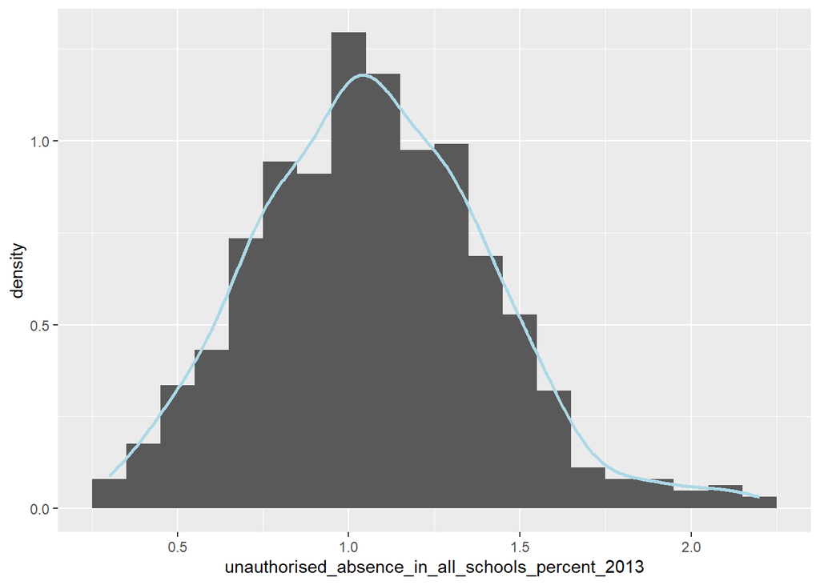

```r
dist_absence <- ggplot(wards_merged,
                    aes(x = unauthorised_absence_in_all_schools_percent_2013)) +
  geom_histogram(aes(y = ..density..),
                 binwidth = 0.1) +
  #Add density line
  geom_density(colour = "lightblue",
               linewidth = 1, adjust = 1)
dist_absence
```

Both variables are roughly normally distributed.

```r
#Create a regression model on its own
model1 <- wards_merged %>%
  lm(average_gcse_capped_point_scores_2014 ~ unauthorised_absence_in_all_schools_percent_2013,
     data = .)

summary(model1)
```

```
##
## Call:
## lm(formula = average_gcse_capped_point_scores_2014 ~ unauthorised_absence_in_all_schools_percent_2013,
##     data = .)
##
## Residuals:
##     Min      1Q  Median      3Q     Max
## -59.753 -10.223  -1.063   8.547  61.842
##
## Coefficients:
##                                                  Estimate Std. Error t value
## (Intercept)                                       371.471      2.165   171.6
## unauthorised_absence_in_all_schools_percent_2013  -41.237      1.927   -21.4
##                                                  Pr(>|t|)
## (Intercept)                                        <2e-16 ***
## unauthorised_absence_in_all_schools_percent_2013   <2e-16 ***
## ---
## Signif. codes:  0 '***' 0.001 '**' 0.01 '*' 0.05 '.' 0.1 ' ' 1
##
## Residual standard error: 16.39 on 624 degrees of freedom
## Multiple R-squared:  0.4233, Adjusted R-squared:  0.4224
## F-statistic:   458 on 1 and 624 DF,  p-value: < 2.2e-16
```

The scatterplot below shows GCSE scores by school absences.

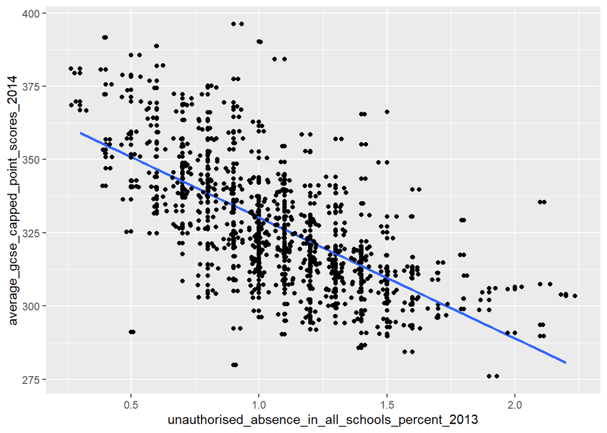

```r
# Create a base scatter plot
q <- qplot(x = unauthorised_absence_in_all_schools_percent_2013,
           y = average_gcse_capped_point_scores_2014,
           data=wards_merged)
#Add a regression line
q + stat_smooth(method="lm", se=FALSE, size=1) +
  #jitter argument used as the x-scale is rounded
  geom_jitter()
```

The assumptions of a linear regression model must then be validated. These are:  
1. Is there a linear association between the variables?  
2. Are the errors independent?  
3. Are the errors normally distributed?  
4. Do the errors have equal variance?

To test these assumptions, the model first needs to be tidied using ‘broom’ and ‘tidypredict’ packages.

```r
#Create a tibble storing the test statistics
broom::tidy(model1)
```

```
## # A tibble: 2 × 5
##   term                                          estim…¹ std.e…² stati…³  p.value
##   <chr>                                           <dbl>   <dbl>   <dbl>    <dbl>
## 1 (Intercept)                                     371.     2.16   172.  0
## 2 unauthorised_absence_in_all_schools_percent_…   -41.2    1.93   -21.4 1.27e-76
## # … with abbreviated variable names ¹estimate, ²std.error, ³statistic
```

```r
#Creates a tibble of the extended regression results
glance(model1)
```

```
## # A tibble: 1 × 12
##   r.squared adj.r.squa…¹ sigma stati…²  p.value    df logLik   AIC   BIC devia…³
##       <dbl>        <dbl> <dbl>   <dbl>    <dbl> <dbl>  <dbl> <dbl> <dbl>   <dbl>
## 1     0.423        0.422  16.4    458. 1.27e-76     1 -2638. 5282. 5296. 167699.
## # … with 2 more variables: df.residual <int>, nobs <int>, and abbreviated
## #   variable names ¹adj.r.squared, ²statistic, ³deviance
```

```r
#Use tidypredict to add a column of expected result given the model
df_model1 <- wards_merged %>% tidypredict_to_column(model1)
```

### Assumption 1: Linear association

Plot a scatterplot to visualise the relationship. See the scatterplot above for confirmation of this assumption.

**Transforming variables for regression**  
If variables are not normally distributed, they will often need to be transformed in some way to make them more appropriate for linear regression. A useful method for this is **Tukey’s Ladder**, which tests different levels of power relationships to see which might have the most normal outcomes.

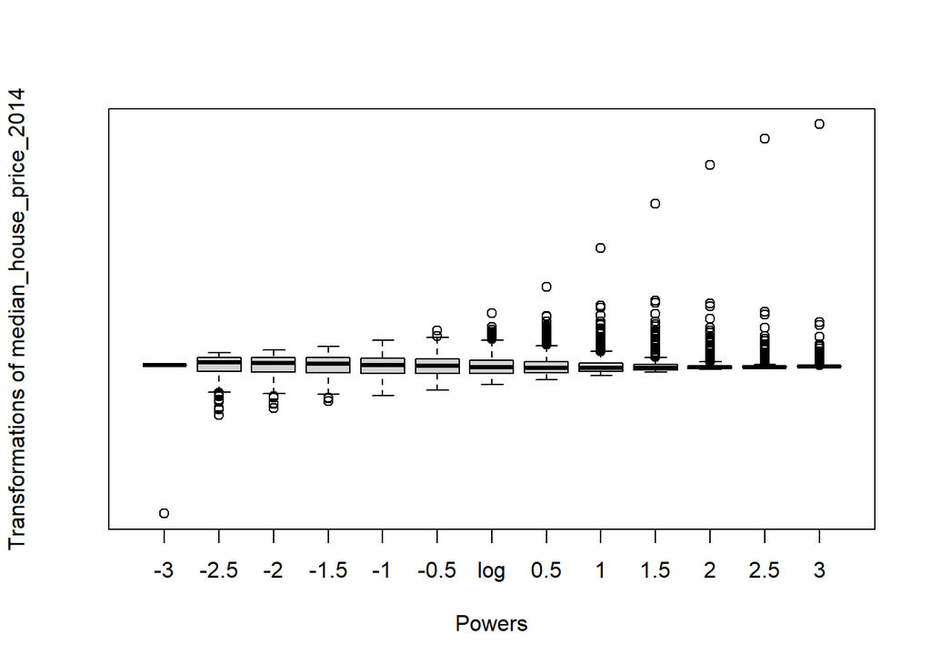

```r
symbox(~median_house_price_2014,
       wards_merged,
       na.rm= TRUE,
       powers = seq(-3, 3, by=0.5))  #vector of powers to which 'x' is raised (here specified as a sequence)
```

The Tukey’s ladder suggests that a power relationship of x raised to the power of -1 will have the closest approximation to a normal distribution. To visualise this in a scatterplot:

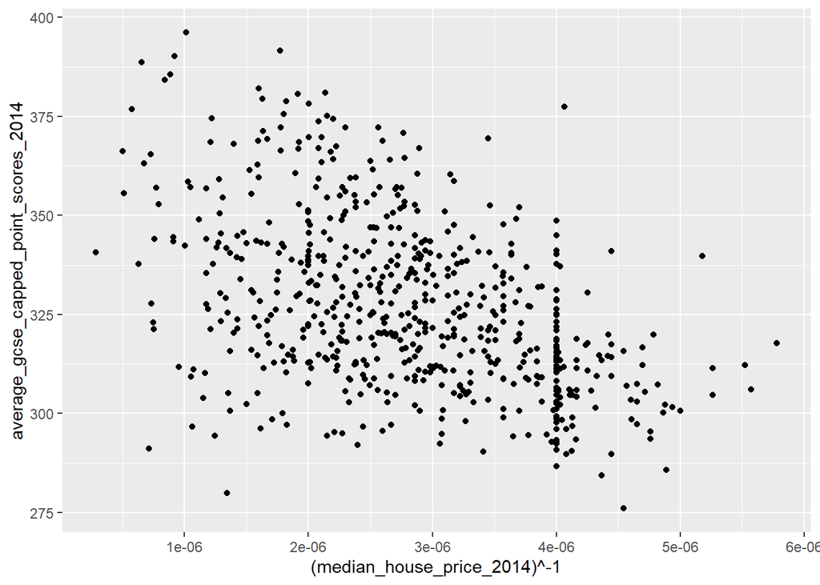

```r
qplot(x = (median_house_price_2014)^-1,
      y = average_gcse_capped_point_scores_2014,
      data=wards_merged)
```

### Assumption 2: Normally distributed errors

Use the ‘augment’ function to store the fitted values and residuals calculated from the model, to plot a histogram of the residuals. From the plot below, we can be satisfied that assumption 2 has been met.

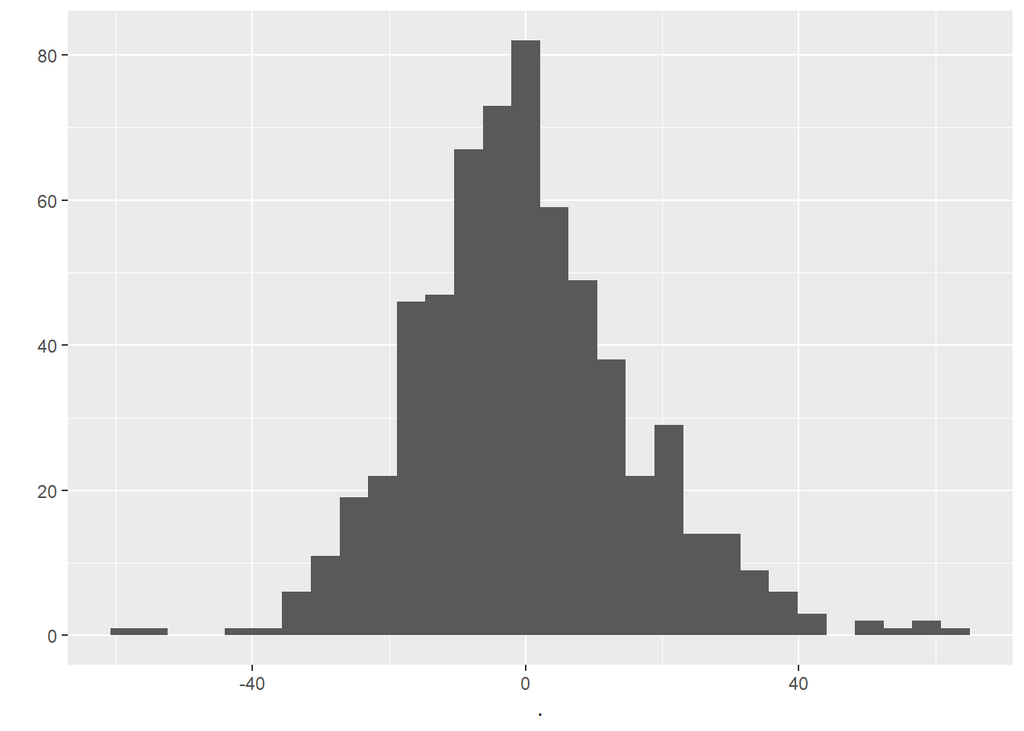

```r
df_model1 <- augment(model1, wards_merged)

#Plot histogram of the residuals
df_model1 %>% select(., .resid) %>%
  pull() %>%
  qplot() +
  geom_histogram()
```

### Assumption 3: Independent errors & errors with equal variance

The best way to quickly assess whether assumption 3 has been met, is to produce a scatter plot of residuals versus fitted values.

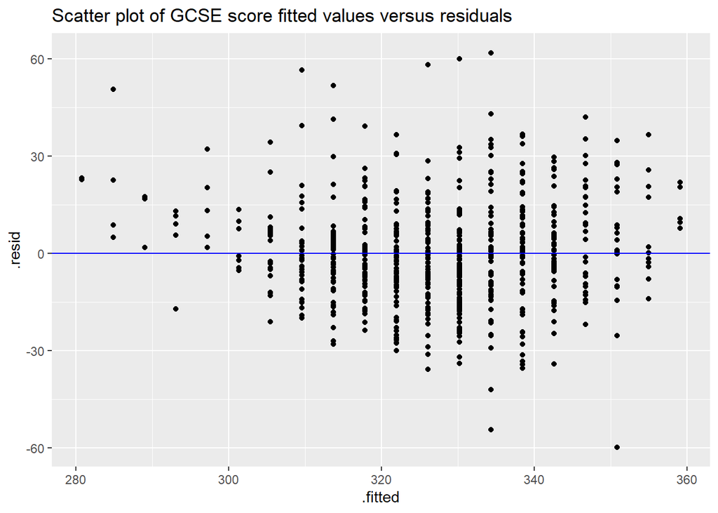

```r
#Quick plot
# qplot(x = .fitted,
#       y = .resid,
#       data=df_model1)

#create using ggplot (better practice)
ggplot(data = df_model1,
       aes(x = .fitted, y = .resid)) +
  geom_point() +
  geom_hline(yintercept = 0,
             color = "blue") +
  labs(title = "Scatter plot of GCSE score fitted values versus residuals")
```

How to interpret this? If residuals (errors) are independent, we would expect to see:  
* The residuals form a roughly horizontal band around the 0 line. This suggests the variance of the errors are equal. * The residuals “bounce randomly” around the 0 line. This suggests that the errors are independent. * No one residual “stands out” from the basic random pattern of residuals. This suggests that there are no outliers.